# Data Mining Project 1

Project Group 10 - Abhilash Narayanan

2024-10-15

```r
library("tidyverse")
```

```r
library("ggplot2")
library("ggrepel")
library("ggcorrplot")
library("DT")
```

# 1. Data Collection and Cleaning

Three datasets are considered for this analysis

1. Dataset 1 : COVID-19_cases_TX.csv
2. Dataset 2 : COVID-19_cases_plus_census.csv ( Cleansing of this is done in a R code uploaded separately)
3. Dataset 4 : COVID-19_Vaccinations

```r
tx_covid_cases <-
read.csv("C:\\Users\\nilee\\Documents\\AbhilashStudy\\DataMining\\COVID-19\\COVID-19_cases_TX.csv",header =
TRUE)
options(max.print=10)

county_census <-
read.csv("C:\\Users\\nilee\\Documents\\AbhilashStudy\\DataMining\\COVID-19\\COVID-19_cases_plus_census.csv",header =
TRUE)
options(max.print=10)

county_vaccination <-
read.csv("C:\\Users\\nilee\\Documents\\AbhilashStudy\\DataMining\\COVID-19\\COVID-19_Vaccinations_in_the_United_States_County.csv",header =
TRUE)
options(max.print=10)
```

Changing the options to print only 10 records while printing Printing summary of COVID dataset

```r
options(max.print=10)
summary(tx_covid_cases)
```

```
##  county_fips_code county_name           state           state_fips_code
##  Min.   :    0    Length:94350       Length:94350       Min.   :48
##      date           confirmed_cases        deaths
##  Length:94350       Min.   :     0.0   Min.   :   0.00
##  [ reached getOption("max.print") -- omitted 5 rows ]
```

Printing the Summary of the Vaccination Dataset

```r
summary(county_vaccination)
```

```
##      Date               FIPS             MMWR_week     Recip_County
##  Recip_State        Completeness_pct Administered_Dose1_Recip
##  Administered_Dose1_Pop_Pct Administered_Dose1_Recip_5Plus
##  Administered_Dose1_Recip_5PlusPop_Pct Administered_Dose1_Recip_12Plus
##  Administered_Dose1_Recip_12PlusPop_Pct Administered_Dose1_Recip_18Plus
##  Administered_Dose1_Recip_18PlusPop_Pct Administered_Dose1_Recip_65Plus
##  Administered_Dose1_Recip_65PlusPop_Pct Series_Complete_Yes
##  Series_Complete_Pop_Pct Series_Complete_5Plus Series_Complete_5PlusPop_Pct
##  Series_Complete_5to17 Series_Complete_5to17Pop_Pct Series_Complete_12Plus
##  Series_Complete_12PlusPop_Pct Series_Complete_18Plus
##  Series_Complete_18PlusPop_Pct Series_Complete_65Plus
##  Series_Complete_65PlusPop_Pct Booster_Doses      Booster_Doses_Vax_Pct
##  Booster_Doses_5Plus Booster_Doses_5Plus_Vax_Pct Booster_Doses_12Plus
##  Booster_Doses_12Plus_Vax_Pct Booster_Doses_18Plus Booster_Doses_18Plus_Vax_Pct
##  Booster_Doses_50Plus Booster_Doses_50Plus_Vax_Pct Booster_Doses_65Plus
##  Booster_Doses_65Plus_Vax_Pct Second_Booster_50Plus
##  Second_Booster_50Plus_Vax_Pct Second_Booster_65Plus
##  Second_Booster_65Plus_Vax_Pct   SVI_CTGY         Series_Complete_Pop_Pct_SVI
##  Series_Complete_5PlusPop_Pct_SVI Series_Complete_5to17Pop_Pct_SVI
##  Series_Complete_12PlusPop_Pct_SVI Series_Complete_18PlusPop_Pct_SVI
##  Series_Complete_65PlusPop_Pct_SVI Metro_status
##  Series_Complete_Pop_Pct_UR_Equity Series_Complete_5PlusPop_Pct_UR_Equity
##  Series_Complete_5to17Pop_Pct_UR_Equity Series_Complete_12PlusPop_Pct_UR_Equity
##  Series_Complete_18PlusPop_Pct_UR_Equity
##  Series_Complete_65PlusPop_Pct_UR_Equity Booster_Doses_Vax_Pct_SVI
##  Booster_Doses_12PlusVax_Pct_SVI Booster_Doses_18PlusVax_Pct_SVI
##  Booster_Doses_65PlusVax_Pct_SVI Booster_Doses_Vax_Pct_UR_Equity
##  Booster_Doses_12PlusVax_Pct_UR_Equity Booster_Doses_18PlusVax_Pct_UR_Equity
##  Booster_Doses_65PlusVax_Pct_UR_Equity  Census2019        Census2019_5PlusPop
##  Census2019_5to17Pop Census2019_12PlusPop Census2019_18PlusPop
##  Census2019_65PlusPop Bivalent_Booster_5Plus Bivalent_Booster_5Plus_Pop_Pct
##  Bivalent_Booster_12Plus Bivalent_Booster_12Plus_Pop_Pct
##  Bivalent_Booster_18Plus Bivalent_Booster_18Plus_Pop_Pct
##  Bivalent_Booster_65Plus Bivalent_Booster_65Plus_Pop_Pct
##  [ reached getOption("max.print") -- omitted 7 rows ]
```

## Data Cleaning Dataset 1

Below are the cleaning activities performed for this dataset:- Removing the records which are Un-allocated to a county as these may not have a value while performing a county level analysis Correcting the data types of the data columns

```r
tx_covid_cases
```

| county_fips_code | county_name | state | state_fips_code | date | confirmed_cases | deaths |
| --- | --- | --- | --- | --- | --- | --- |
| 0 | Statewide Unallocated | TX | 48 | 1/22/2020 | 0 | 0 |
| 0 | Statewide Unallocated | TX | 48 | 1/23/2020 | 0 | 0 |
| 0 | Statewide Unallocated | TX | 48 | 1/24/2020 | 0 | 0 |
| 0 | Statewide Unallocated | TX | 48 | 1/25/2020 | 0 | 0 |
| 0 | Statewide Unallocated | TX | 48 | 1/26/2020 | 0 | 0 |
| 0 | Statewide Unallocated | TX | 48 | 1/27/2020 | 0 | 0 |
| 0 | Statewide Unallocated | TX | 48 | 1/28/2020 | 0 | 0 |
| 0 | Statewide Unallocated | TX | 48 | 1/29/2020 | 0 | 0 |
| 0 | Statewide Unallocated | TX | 48 | 1/30/2020 | 0 | 0 |
| 0 | Statewide Unallocated | TX | 48 | 1/31/2020 | 0 | 0 |

```r
tx_covid_cases <- subset(tx_covid_cases,county_name !='Statewide Unallocated')
tx_covid_cases$date <- as.Date(tx_covid_cases$date,format = "%m/%d/%Y")
options(max.print=10)
tx_covid_cases
```

|  | county_fips_code | county_name | state | state_fips_code | date | confirmed_cases | deaths |
| --- | --- | --- | --- | --- | --- | --- | --- |
| 371 | 48001 | Anderson County | TX | 48 | 2020-01-22 | 0 | 0 |
| 372 | 48001 | Anderson County | TX | 48 | 2020-01-23 | 0 | 0 |
| 373 | 48001 | Anderson County | TX | 48 | 2020-01-24 | 0 | 0 |
| 374 | 48001 | Anderson County | TX | 48 | 2020-01-25 | 0 | 0 |
| 375 | 48001 | Anderson County | TX | 48 | 2020-01-26 | 0 | 0 |
| 376 | 48001 | Anderson County | TX | 48 | 2020-01-27 | 0 | 0 |
| 377 | 48001 | Anderson County | TX | 48 | 2020-01-28 | 0 | 0 |
| 378 | 48001 | Anderson County | TX | 48 | 2020-01-29 | 0 | 0 |
| 379 | 48001 | Anderson County | TX | 48 | 2020-01-30 | 0 | 0 |
| 380 | 48001 | Anderson County | TX | 48 | 2020-01-31 | 0 | 0 |

## Data Cleaning Dataset 4

Correcting the data type of the “Date” feature Changing the data type of all numeric fields by removing commas

```r
county_vaccination$Date <- as.Date(county_vaccination$Date,format = "%m/%d/%Y")
county_vaccination$Administered_Dose1_Recip <- as.numeric(gsub(",","",county_vaccination$Administered_Dose1_Recip,fixed=TRUE))
county_vaccination$Series_Complete_Yes <- as.numeric(gsub(",","",county_vaccination$Series_Complete_Yes,fixed=TRUE))
county_vaccination$Booster_Doses <- as.numeric(gsub(",","",county_vaccination$Booster_Doses,fixed=TRUE))
county_vaccination$Census2019 <- as.numeric(gsub(",","",county_vaccination$Census2019,fixed=TRUE))
options(max.print=10)
county_vaccination
```

| Date | FIPS | MMWR_week | Recip_County | Recip_State | Completeness_pct | Administered_Dose1_Recip | Administered_Dose1_Pop_Pct | Administered_Dose1_Recip_5Plus | Administered_Dose1_Recip_5PlusPop_Pct | Administered_Dose1_Recip_12Plus | Administered_Dose1_Recip_12PlusPop_Pct | Administered_Dose1_Recip_18Plus | Administered_Dose1_Recip_18PlusPop_Pct | Administered_Dose1_Recip_65Plus | Administered_Dose1_Recip_65PlusPop_Pct | Series_Complete_Yes | Series_Complete_Pop_Pct | Series_Complete_5Plus | Series_Complete_5PlusPop_Pct | Series_Complete_5to17 | Series_Complete_5to17Pop_Pct | Series_Complete_12Plus | Series_Complete_12PlusPop_Pct | Series_Complete_18Plus | Series_Complete_18PlusPop_Pct | Series_Complete_65Plus | Series_Complete_65PlusPop_Pct | Booster_Doses | Booster_Doses_Vax_Pct | … |
| --- | --- | --- | --- | --- | --- | --- | --- | --- | --- | --- | --- | --- | --- | --- | --- | --- | --- | --- | --- | --- | --- | --- | --- | --- | --- | --- | --- | --- | --- | --- |
| 2023-05-10 | 48281 | 19 | Lampasas County | TX | 98.9 | 11678 | 54.5 | 11,660 | 57.4 | 11,468 | 61.9 | 10,849 | 64.6 | 3,920 | 90.7 | 10007 | 46.7 | 9,999 | 49.2 | 669 | 19.0 | 9,845 | 53.2 | 9,330 | 55.5 | 3,448 | 79.8 | 4217 | 42.1 | … |
| 2023-05-10 | 48421 | 19 | Sherman County | TX | 98.9 | 1367 | 45.2 | 1,364 | 48.2 | 1,353 | 53.9 | 1,294 | 58.4 | 295 | 63.9 | 1057 | 35.0 | 1,057 | 37.4 | 43 | 7.0 | 1,050 | 41.8 | 1,014 | 45.8 | 245 | 53.0 | 254 | 24.0 | … |
| 2023-05-10 | 48499 | 19 | Wood County | TX | 98.9 | 22231 | 48.8 | 22,219 | 51.2 | 22,034 | 55.0 | 21,391 | 57.9 | 9,897 | 79.0 | 19990 | 43.9 | 19,988 | 46.1 | 692 | 10.8 | 19,856 | 49.6 | 19,296 | 52.2 | 9,196 | 73.4 | 9208 | 46.1 | … |
| 2023-05-10 | 48137 | 19 | Edwards County | TX | 98.9 | 2053 | 95.0 | 2,032 | 95.0 | 1,921 | 95.0 | 1,825 | 95.0 | 649 | 95.0 | 1721 | 89.1 | 1,709 | 93.9 | 153 | 49.7 | 1,625 | 95.0 | 1,556 | 95.0 | 555 | 95.0 | 741 | 43.1 | … |
| 2023-05-10 | 48117 | 19 | Deaf Smith County | TX | 98.9 | 9400 | 50.7 | 9,388 | 55.4 | 9,124 | 62.0 | 8,403 | 65.5 | 2,087 | 86.1 | 8154 | 44.0 | 8,149 | 48.1 | 805 | 19.6 | 7,959 | 54.1 | 7,344 | 57.3 | 1,885 | 77.8 | 2974 | 36.5 | … |
| 2023-05-10 | 48005 | 19 | Angelina County | TX | 98.9 | 46693 | 53.8 | 46,643 | 57.6 | 45,688 | 63.2 | 42,976 | 66.5 | 12,525 | 86.8 | 41266 | 47.6 | 41,258 | 51.0 | 3,017 | 18.5 | 40,568 | 56.1 | 38,241 | 59.1 | 11,623 | 80.6 | 17165 | 41.6 | … |
| 2023-05-10 | 48165 | 19 | Gaines County | TX | 98.9 | 5561 | 25.9 | 5,554 | 28.9 | 5,406 | 33.2 | 5,050 | 36.8 | 1,118 | 58.6 | 4780 | 22.2 | 4,777 | 24.8 | 395 | 7.2 | 4,671 | 28.7 | 4,382 | 31.9 | 1,007 | 52.8 | 1374 | 28.7 | … |
| 2023-05-10 | 48031 | 19 | Blanco County | TX | 98.9 | 8205 | 68.8 | 8,192 | 71.6 | 8,088 | 75.8 | 7,759 | 79.1 | 3,116 | 95.0 | 6932 | 58.1 | 6,927 | 60.5 | 344 | 21.1 | 6,846 | 64.2 | 6,583 | 67.1 | 2,712 | 90.3 | 3155 | 45.5 | … |
| 2023-05-10 | 48295 | 19 | Lipscomb County | TX | 98.9 | 1341 | 41.5 | 1,339 | 43.9 | 1,330 | 48.9 | 1,290 | 53.4 | 495 | 80.2 | 1124 | 34.8 | 1,124 | 36.9 | 37 | 5.8 | 1,118 | 41.1 | 1,087 | 45.0 | 421 | 68.2 | 404 | 35.9 | … |
| 2023-05-10 | 48055 | 19 | Caldwell County | TX | 98.9 | 30364 | 69.5 | 30,208 | 73.8 | 29,100 | 78.3 | 26,483 | 79.0 | 6,202 | 95.0 | 25349 | 58.1 | 25,311 | 61.8 | 2,840 | 38.2 | 24,618 | 66.2 | 22,471 | 67.1 | 5,380 | 82.6 | 10167 | 40.1 | … |

Summary of the COVID cases and Death by County

```r
tx_covid_cases_county = subset(tx_covid_cases, date == '2021-01-25') %>% group_by(county_name)  %>%
                    summarise(total_confirmed_cases = sum(confirmed_cases),
                              total_deaths = sum(deaths),
                              .groups = 'drop')
tx_covid_cases_county$death_perc=tx_covid_cases_county$total_deaths*100/tx_covid_cases_county$total_confirmed_cases
tx_covid_cases_county <- tx_covid_cases_county[order(tx_covid_cases_county$death_perc,
                                decreasing = TRUE), ]
tx_covid_cases_county
```

| county_name | total_confirmed_cases | total_deaths | death_perc |
| --- | --- | --- | --- |
| Sherman County | 120 | 11 | 9.166667 |
| Motley County | 80 | 7 | 8.750000 |
| Kenedy County | 30 | 2 | 6.666667 |
| Sabine County | 463 | 30 | 6.479482 |
| Garza County | 284 | 18 | 6.338028 |
| San Augustine County | 502 | 28 | 5.577689 |
| Knox County | 216 | 12 | 5.555556 |
| Cochran County | 220 | 12 | 5.454545 |
| Crosby County | 405 | 22 | 5.432099 |
| Red River County | 572 | 31 | 5.419580 |

# 2. Data Analysis

## CoVID Data Set

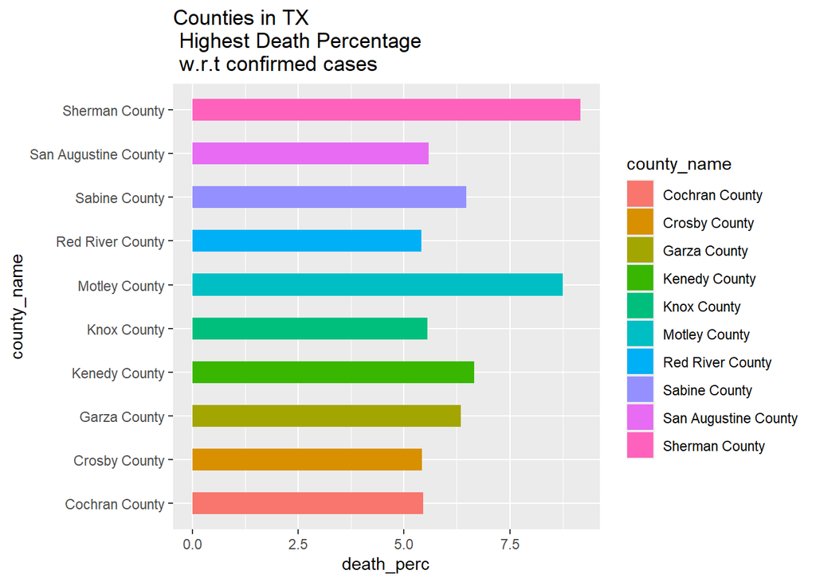

```r
ggplot(head(tx_covid_cases_county,10),
           aes(x=county_name, y=death_perc,fill=county_name)) +
  geom_bar(stat="identity",width=0.5) +
  ggtitle("Counties in TX \n Highest Death Percentage \n w.r.t confirmed cases")+
  coord_flip()
```

```r
head
```

```
## function (x, ...)
## UseMethod("head")
## <bytecode: 0x0000029214f74300>
## <environment: namespace:utils>
```

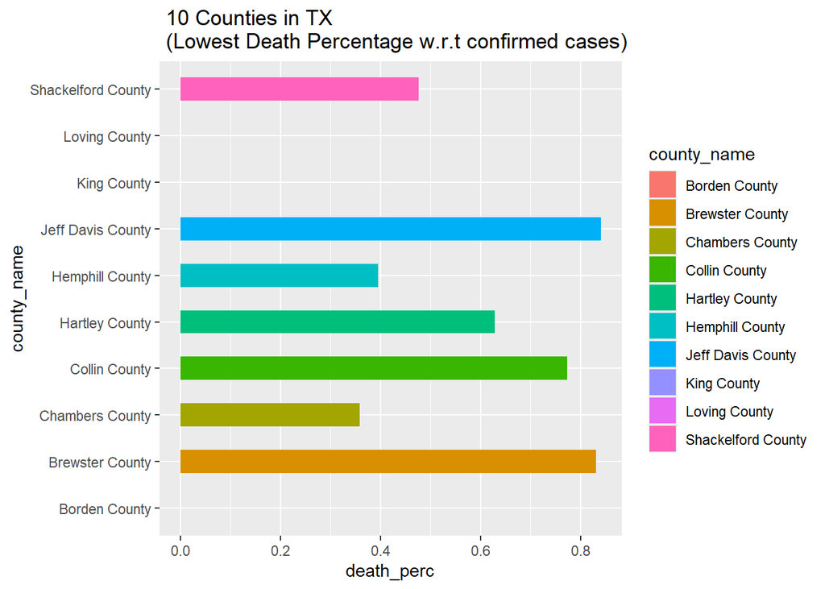

```r
ggplot(tail(tx_covid_cases_county,10),
           aes(x=county_name, y=death_perc,fill=county_name)) +
  geom_bar(stat="identity",width=0.5) +
  ggtitle(" 10 Counties in TX \n (Lowest Death Percentage w.r.t confirmed cases)")+
  coord_flip()
```

```r
head
```

```
## function (x, ...)
## UseMethod("head")
## <bytecode: 0x0000029214f74300>
## <environment: namespace:utils>
```

Creating the County dataset from Map for Tx state This will be joined with the Cases dataset to plot the same in the graph

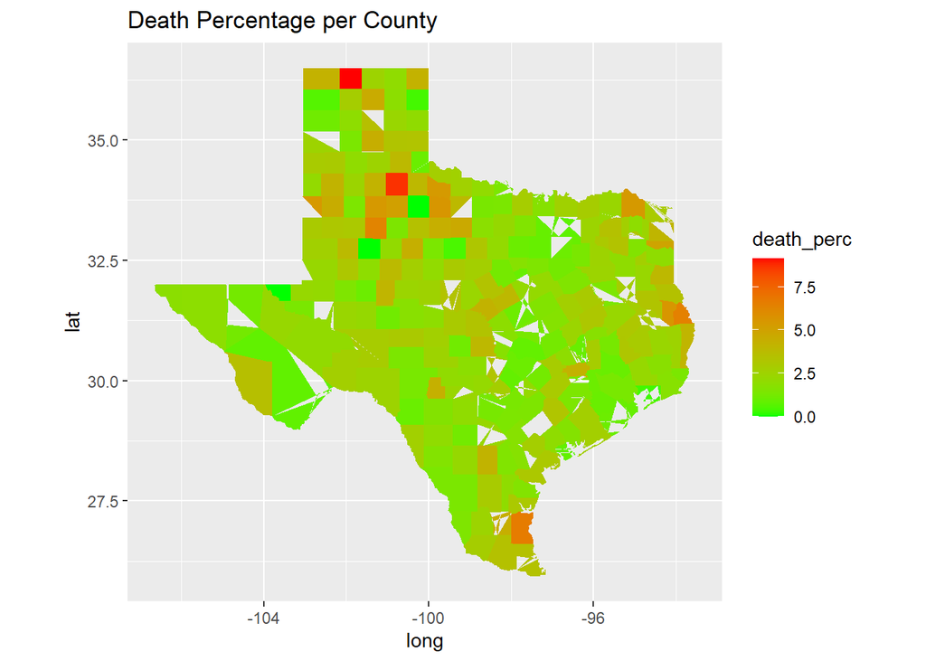

```r
counties <- as_tibble(map_data("county"))
counties_TX <- counties %>% dplyr::filter(region == "texas") %>% rename(c(county = subregion))

tx_covid_cases_county <- tx_covid_cases_county %>% mutate(county = county_name %>% str_to_lower() %>%
    str_replace('\\s+county\\s*$', ''))

counties_w_map<-merge(x = counties_TX, y = tx_covid_cases_county, by = "county")


ggplot(counties_w_map, aes(long, lat, label = county)) +
  geom_polygon(aes(group = group, fill = death_perc)) +
  scale_fill_gradient(low="green", high="red") +
  coord_quickmap() +
  labs(title = "Death Percentage per County")
```

### Filtering only TX Counties for Census data

```r
county_census <- subset(county_census,state == 'TX')
county_census <- county_census %>% mutate(county = county_name %>% str_to_lower() %>%
    str_replace('\\s+county\\s*$', ''))
```

### Joining the Covid data with the Census data

```r
covid_cases_w_census<-merge(x = county_census, y = tx_covid_cases_county, by = "county")
```

### Is there a relation between median income and death percentage of a county?

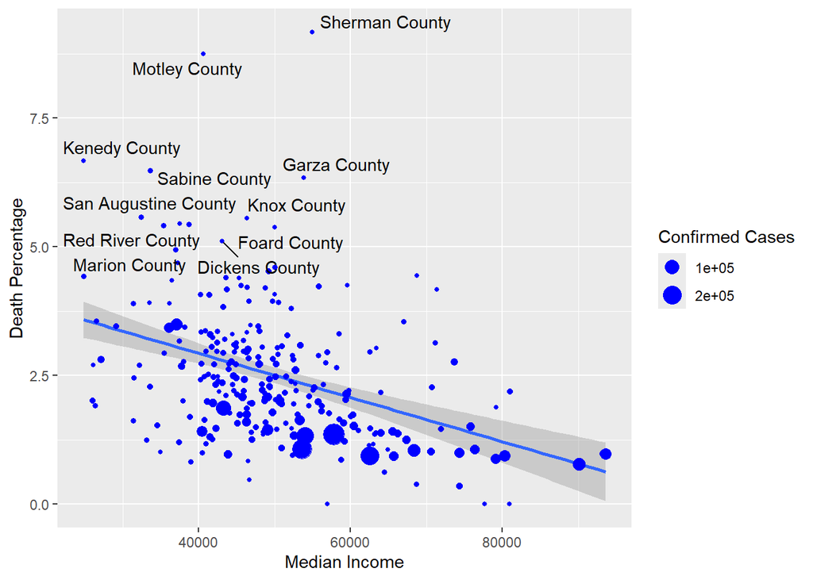

```r
ggplot(covid_cases_w_census, mapping = aes(x= median_income, y = death_perc, label = county_name.x)) +
  geom_smooth(method = lm) +
  geom_point(mapping = aes(size = total_confirmed_cases), color = "blue") +
  geom_text_repel(data = subset(covid_cases_w_census, death_perc > quantile(death_perc, .95))) +
  labs(x = "Median Income", y = "Death Percentage", size = "Confirmed Cases")
```

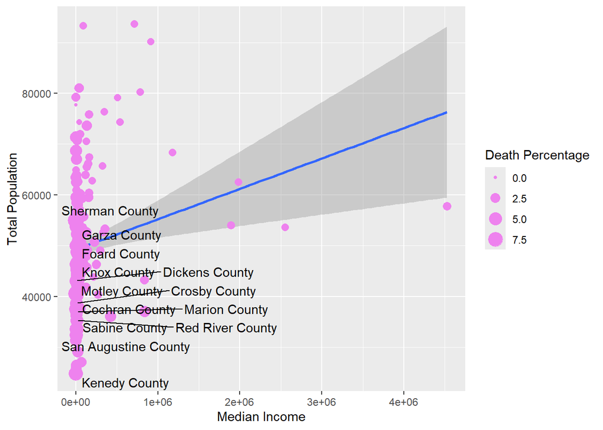

```r
ggplot(covid_cases_w_census, mapping = aes(x= total_pop, y = median_income, label = county_name.x)) +
  geom_smooth(method = lm) +
  geom_point(mapping = aes(size = death_perc), color = "violet") +
  geom_text_repel(data = subset(covid_cases_w_census, death_perc > quantile(death_perc, .95))) +
  labs(x = "Median Income", y = "Total Population", size = "Death Percentage")
```

Total Population do not have much effect on teh death percentage compared to the median income. If the MEdian Income of a county is lower , irrespective of the total population , these counties seem to have a higher death percentage

### Did we flatten the curve?

Logic to add total confirmed cases - previous day total confirmed cases

```r
tx_covid_cases_date = tx_covid_cases %>% group_by(date) %>%
summarise(total_confirmed_cases = sum(confirmed_cases),
total_deaths = sum(deaths),
.groups = 'drop')
tx_covid_cases_date <- mutate(tx_covid_cases_date, prev_day_case=lag(total_confirmed_cases, order_by = date))
tx_covid_cases_date$daily_increase<- tx_covid_cases_date$total_confirmed_cases-tx_covid_cases_date$prev_day_case
tx_covid_cases_date
```

| date | total_confirmed_cases | total_deaths | prev_day_case | daily_increase |
| --- | --- | --- | --- | --- |
| 2020-01-22 | 0 | 0 | NA | NA |
| 2020-01-23 | 0 | 0 | 0 | 0 |
| 2020-01-24 | 0 | 0 | 0 | 0 |
| 2020-01-25 | 0 | 0 | 0 | 0 |
| 2020-01-26 | 0 | 0 | 0 | 0 |
| 2020-01-27 | 0 | 0 | 0 | 0 |
| 2020-01-28 | 0 | 0 | 0 | 0 |
| 2020-01-29 | 0 | 0 | 0 | 0 |
| 2020-01-30 | 0 | 0 | 0 | 0 |
| 2020-01-31 | 0 | 0 | 0 | 0 |

Plotting that in a line graph

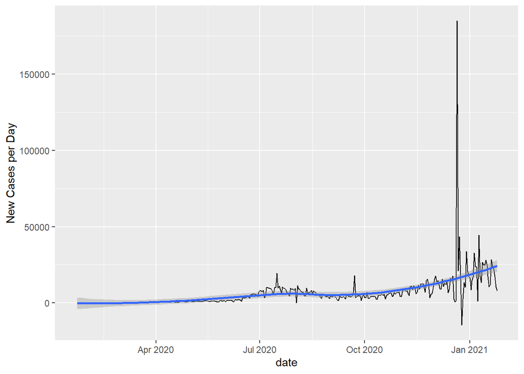

```r
ggplot(tx_covid_cases_date, aes(x = date, y = daily_increase)) +
  geom_line() +
  geom_smooth() +
  labs(y = "New Cases per Day")
```

### Finding Corelated features

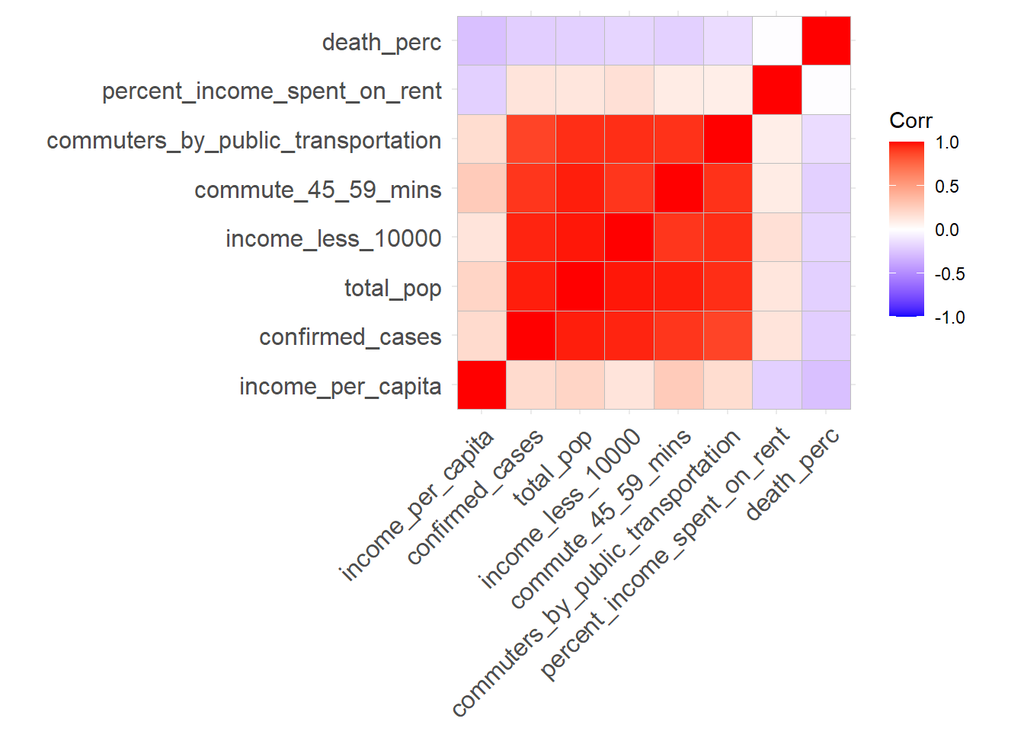

```r
cor_cases=cor(select(covid_cases_w_census,confirmed_cases,total_pop,percent_income_spent_on_rent, confirmed_cases,commute_45_59_mins,income_less_10000,commuters_by_public_transportation,income_per_capita,death_perc))
ggcorrplot(cor_cases,insig = "blank", hc.order = TRUE)
```

## Dataset 4: COVID Vaccination Report

Pivoting the data to display multiple line graphs

```r
county_vacc_date = county_vaccination %>% group_by(Date) %>%
summarise(tot_dose1 = sum(Administered_Dose1_Recip),
        tot_series_complete = sum(Series_Complete_Yes),
        tot_booster = sum(Booster_Doses),
.groups = 'drop')

county_vacc_date_pivot <- county_vacc_date %>%
  select(Date, tot_dose1, tot_series_complete,tot_booster) %>%
  gather(key = "vaccination_type", value = "value", -Date)
county_vacc_date_pivot
```

| Date | vaccination_type | value |
| --- | --- | --- |
| 2020-12-13 | tot_dose1 | 0 |
| 2020-12-14 | tot_dose1 | 0 |
| 2020-12-15 | tot_dose1 | 0 |
| 2020-12-16 | tot_dose1 | 0 |
| 2020-12-17 | tot_dose1 | 0 |
| 2020-12-18 | tot_dose1 | 0 |
| 2020-12-19 | tot_dose1 | 0 |
| 2020-12-20 | tot_dose1 | 0 |
| 2020-12-21 | tot_dose1 | 0 |
| 2020-12-22 | tot_dose1 | 0 |

Plotting the pivoted data set to a line graph

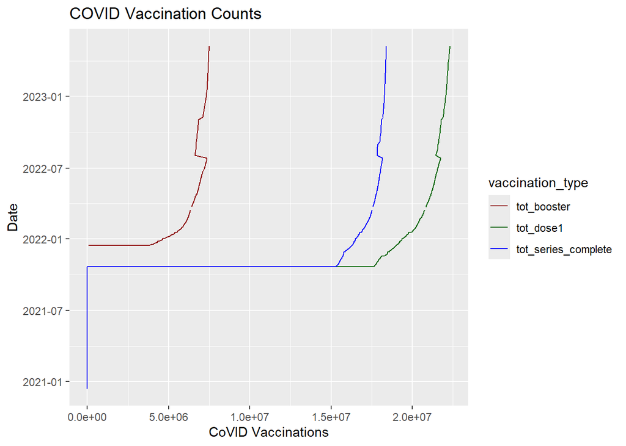

```r
ggplot(county_vacc_date_pivot, aes(x = Date, y = value)) +
  geom_line(aes(color = vaccination_type, line_type = 1)) +
  scale_color_manual(values = c("darkred", "darkgreen","blue")) +
  labs(y = "CoVID Vaccinations", x="Date", title="COVID Vaccination Counts")+
  coord_flip()
```

### Calculating the Booster Doses /1000

```r
tx_covid_vacc_county <- county_vaccination %>% mutate(county = Recip_County %>% str_to_lower() %>%
    str_replace('\\s+county\\s*$', ''))

tx_covid_vacc_county = subset(tx_covid_vacc_county, Date == '2023-05-10')

tx_covid_vacc_county$Booster_per_1000 = (tx_covid_vacc_county$Booster_Doses*1000)/ tx_covid_vacc_county$Census2019

vacc_w_map<-merge(x = counties_TX, y = tx_covid_vacc_county, by = "county")

vacc_w_map$Booster_per_1000 = vacc_w_map$Booster_Doses*1000/vacc_w_map$Census2019

vacc_w_map
```

| county | long | lat | group | order | region | Date | FIPS | MMWR_week | Recip_County | Recip_State | Completeness_pct | Administered_Dose1_Recip | Administered_Dose1_Pop_Pct | Administered_Dose1_Recip_5Plus | Administered_Dose1_Recip_5PlusPop_Pct | Administered_Dose1_Recip_12Plus | Administered_Dose1_Recip_12PlusPop_Pct | Administered_Dose1_Recip_18Plus | Administered_Dose1_Recip_18PlusPop_Pct | Administered_Dose1_Recip_65Plus | Administered_Dose1_Recip_65PlusPop_Pct | Series_Complete_Yes | Series_Complete_Pop_Pct | Series_Complete_5Plus | Series_Complete_5PlusPop_Pct | Series_Complete_5to17 | Series_Complete_5to17Pop_Pct | Series_Complete_12Plus | Series_Complete_12PlusPop_Pct | … |
| --- | --- | --- | --- | --- | --- | --- | --- | --- | --- | --- | --- | --- | --- | --- | --- | --- | --- | --- | --- | --- | --- | --- | --- | --- | --- | --- | --- | --- | --- | --- |
| anderson | -95.77563 | 31.63300 | 2492 | 74528 | texas | 2023-05-10 | 48001 | 19 | Anderson County | TX | 98.9 | 26562 | 46 | 26,550 | 48.5 | 26,293 | 52 | 25,487 | 54.5 | 6,334 | 73.2 | 23445 | 40.6 | 23,443 | 42.8 | 886 | 11 | 23,239 | 46 | … |
| anderson | -95.81000 | 31.67311 | 2492 | 74530 | texas | 2023-05-10 | 48001 | 19 | Anderson County | TX | 98.9 | 26562 | 46 | 26,550 | 48.5 | 26,293 | 52 | 25,487 | 54.5 | 6,334 | 73.2 | 23445 | 40.6 | 23,443 | 42.8 | 886 | 11 | 23,239 | 46 | … |
| anderson | -95.79282 | 31.71321 | 2492 | 74531 | texas | 2023-05-10 | 48001 | 19 | Anderson County | TX | 98.9 | 26562 | 46 | 26,550 | 48.5 | 26,293 | 52 | 25,487 | 54.5 | 6,334 | 73.2 | 23445 | 40.6 | 23,443 | 42.8 | 886 | 11 | 23,239 | 46 | … |
| anderson | -95.82146 | 31.70748 | 2492 | 74532 | texas | 2023-05-10 | 48001 | 19 | Anderson County | TX | 98.9 | 26562 | 46 | 26,550 | 48.5 | 26,293 | 52 | 25,487 | 54.5 | 6,334 | 73.2 | 23445 | 40.6 | 23,443 | 42.8 | 886 | 11 | 23,239 | 46 | … |
| anderson | -95.79855 | 31.63873 | 2492 | 74529 | texas | 2023-05-10 | 48001 | 19 | Anderson County | TX | 98.9 | 26562 | 46 | 26,550 | 48.5 | 26,293 | 52 | 25,487 | 54.5 | 6,334 | 73.2 | 23445 | 40.6 | 23,443 | 42.8 | 886 | 11 | 23,239 | 46 | … |
| anderson | -95.87876 | 31.75332 | 2492 | 74534 | texas | 2023-05-10 | 48001 | 19 | Anderson County | TX | 98.9 | 26562 | 46 | 26,550 | 48.5 | 26,293 | 52 | 25,487 | 54.5 | 6,334 | 73.2 | 23445 | 40.6 | 23,443 | 42.8 | 886 | 11 | 23,239 | 46 | … |
| anderson | -95.91887 | 31.78197 | 2492 | 74535 | texas | 2023-05-10 | 48001 | 19 | Anderson County | TX | 98.9 | 26562 | 46 | 26,550 | 48.5 | 26,293 | 52 | 25,487 | 54.5 | 6,334 | 73.2 | 23445 | 40.6 | 23,443 | 42.8 | 886 | 11 | 23,239 | 46 | … |
| anderson | -95.94751 | 31.78197 | 2492 | 74536 | texas | 2023-05-10 | 48001 | 19 | Anderson County | TX | 98.9 | 26562 | 46 | 26,550 | 48.5 | 26,293 | 52 | 25,487 | 54.5 | 6,334 | 73.2 | 23445 | 40.6 | 23,443 | 42.8 | 886 | 11 | 23,239 | 46 | … |
| anderson | -95.98762 | 31.80489 | 2492 | 74537 | texas | 2023-05-10 | 48001 | 19 | Anderson County | TX | 98.9 | 26562 | 46 | 26,550 | 48.5 | 26,293 | 52 | 25,487 | 54.5 | 6,334 | 73.2 | 23445 | 40.6 | 23,443 | 42.8 | 886 | 11 | 23,239 | 46 | … |
| anderson | -95.98189 | 31.83927 | 2492 | 74538 | texas | 2023-05-10 | 48001 | 19 | Anderson County | TX | 98.9 | 26562 | 46 | 26,550 | 48.5 | 26,293 | 52 | 25,487 | 54.5 | 6,334 | 73.2 | 23445 | 40.6 | 23,443 | 42.8 | 886 | 11 | 23,239 | 46 | … |

### Plotting the Booster_per_1000 doses on a map

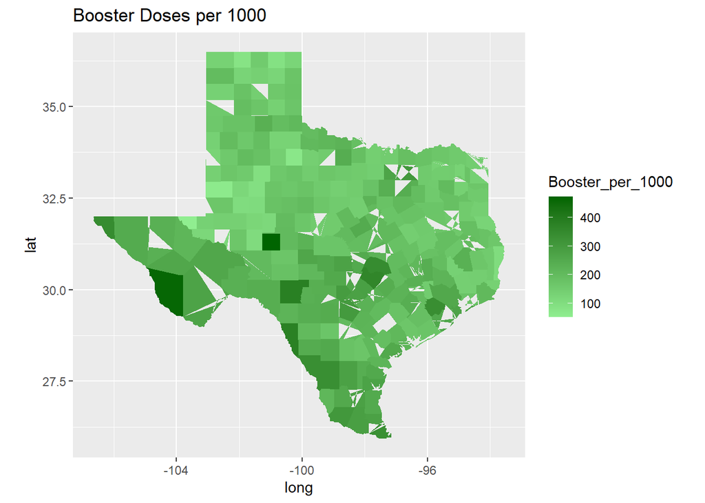

```r
ggplot(vacc_w_map, aes(long, lat, label = county)) +
  geom_polygon(aes(group = group, fill = Booster_per_1000)) +
  scale_fill_gradient(low="lightgreen", high="darkgreen") +
  coord_quickmap() +
  labs(title = "Booster Doses per 1000")
```

### Merging this with the Census data

```r
covid_vacc_w_census<-merge(x = county_census, y = tx_covid_vacc_county, by = "county")
```

### Is there a relation for Booster vaccines and Median Income?

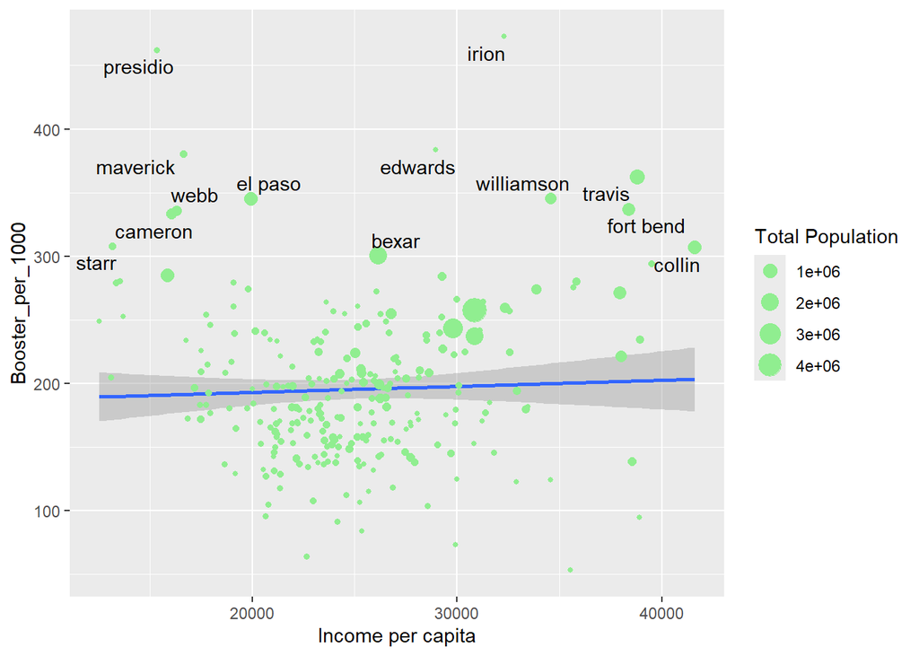

```r
ggplot(covid_vacc_w_census, mapping = aes(x= income_per_capita, y = Booster_per_1000, label = county)) +
  geom_smooth(method = lm) +
  geom_point(mapping = aes(size = total_pop), color = "lightgreen") +
  geom_text_repel(data = subset(covid_vacc_w_census, Booster_per_1000 > quantile(Booster_per_1000, .95))) +
  labs(x = "Income per capita", y = "Booster_per_1000", size = "Total Population")
```

It seems like the Booster vaccine shots do not have direct co-relation between Income and total population

```r
covid_vacc_w_cases<-merge(x = tx_covid_cases_county, y = tx_covid_vacc_county, by = "county")
```

### Can we establish any relationship with Booster shots and COVID cases?

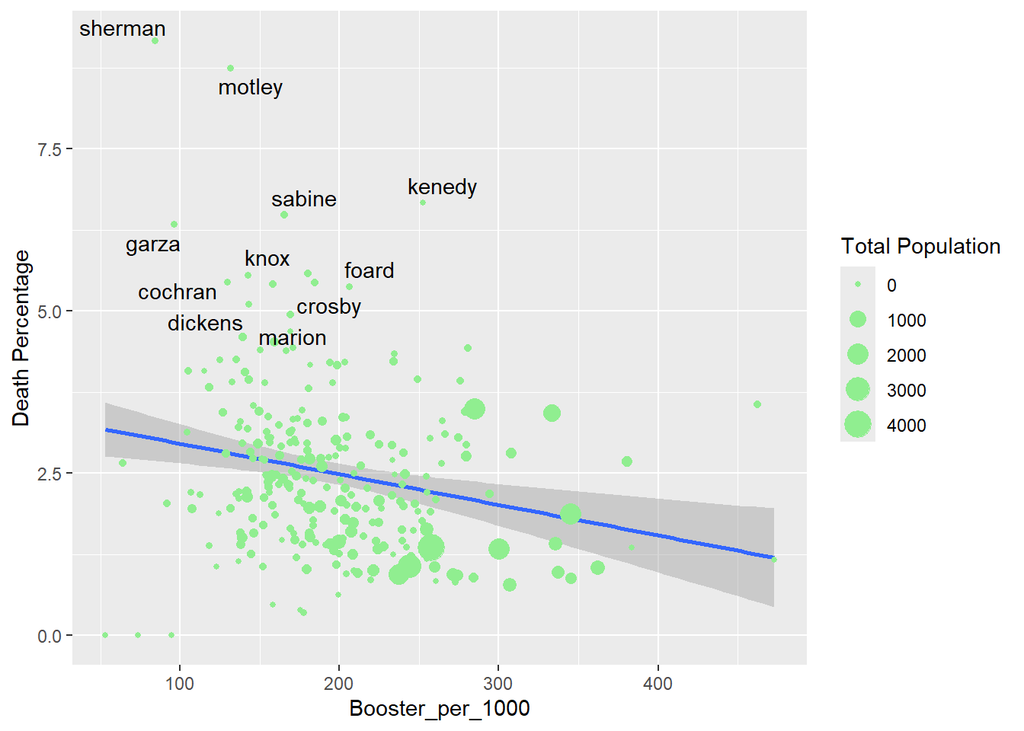

```r
ggplot(covid_vacc_w_cases, mapping = aes(x= Booster_per_1000, y = death_perc, label = county)) +
  geom_smooth(method = lm) +
  geom_point(mapping = aes(size = total_deaths), color = "lightgreen") +
  geom_text_repel(data = subset(covid_vacc_w_cases, death_perc > quantile(death_perc, .95))) +
  labs(x = "Booster_per_1000", y = "Death Percentage", size = "Total Population")
```